# SingleR

Cell type Annotation

Sung Rye Park

2024-12-03

Packages

- SingleR (Good fit for Human, immune cell anntation)

## SingleR

### Processing

```r
library(SingleR)
library(celldex)
library(SingleCellExperiment)

# SingleCellExperiment

count.mtx = obj.srt@assays$RNA@layers$counts
rownames(count.mtx) = rownames(obj.srt)
colnames(count.mtx) = colnames(obj.srt)

sce <- SingleCellExperiment(assays = list(counts = count.mtx))

# ls('package:celldex')
# ref <- HumanPrimaryCellAtlasData()
ref <- MouseRNAseqData()

# logcounts : to use MouseRNAseqData, count should be logcounts
assay(sce, "logcounts") <- log1p(assay(sce, "counts"))

# Annotation
# pred <- SingleR(test = sce, ref = ref, labels = ref$label.main)
pred2 <- SingleR(test = sce, ref = ref, labels = ref$label.fine)
# pred2$pruned.labels %>% table()
pred2 %>% saveRDS(paste0(dir,"rds/pred2_singleR.rds"))
obj.srt$singleR_label = pred2[colnames(obj.srt),]$labels
```

```r
pred2 = readRDS(paste0(dir,"rds/pred2_singleR.rds"))
obj.srt$singleR_label = pred2[colnames(obj.srt),]$labels
```

### SingleR annotation

#### UMAP (split)

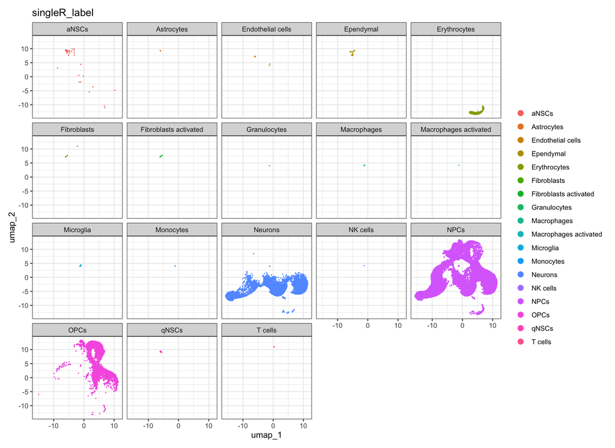

```r
DimPlot(obj.srt, group.by = "singleR_label",
        split.by = "singleR_label", ncol = 5, pt.size = 0.1) +theme_bw()
```

#### Selected Cell Types (split)

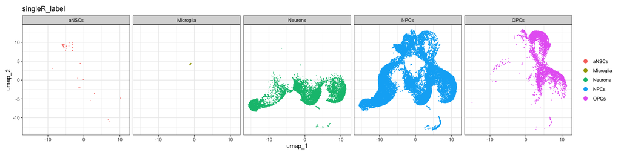

```r
obj.tmp = subset(obj.srt, singleR_label %in% c("Neurons", "NPCs", "OPCs","aNSCs","Microglia"))
DimPlot(obj.tmp, group.by = "singleR_label",
        split.by = "singleR_label", ncol = 5, pt.size = 0.1) +theme_bw()
```

### Annotation Table

```r
obj.srt@meta.data %>% select(RNA_snn_res.0.4, singleR_label) %>% table() %>% data.frame() %>% tidyr::spread(RNA_snn_res.0.4, Freq) %>%
  DT::datatable(extensions = "Buttons",
                width = "800px",
                options = list(scrollX=TRUE,
                               dom="Bfrtip",
                               buttons=c("csv","excel")))
```

|  | singleR_label | 0 | 1 | 2 | 3 | 4 | 5 | 6 | 7 | 8 | 9 | 10 | 11 | 12 | 13 | 14 | 15 | 16 | 17 |
| --- | --- | --- | --- | --- | --- | --- | --- | --- | --- | --- | --- | --- | --- | --- | --- | --- | --- | --- | --- |
| 1 | aNSCs | 2 | 1 | 0 | 0 | 0 | 4 | 0 | 1 | 0 | 32 | 0 | 2 | 0 | 0 | 0 | 0 | 0 | 1 |
| 2 | Astrocytes | 0 | 0 | 0 | 0 | 0 | 0 | 0 | 0 | 0 | 2 | 0 | 0 | 0 | 0 | 0 | 0 | 0 | 0 |
| 3 | Endothelial cells | 0 | 0 | 0 | 0 | 0 | 0 | 0 | 0 | 0 | 0 | 0 | 0 | 0 | 0 | 0 | 0 | 0 | 15 |
| 4 | Ependymal | 0 | 0 | 0 | 0 | 0 | 0 | 0 | 0 | 0 | 22 | 0 | 0 | 0 | 0 | 0 | 0 | 0 | 0 |
| 5 | Erythrocytes | 0 | 0 | 0 | 0 | 0 | 0 | 0 | 0 | 0 | 0 | 0 | 1727 | 0 | 0 | 0 | 0 | 0 | 0 |
| 6 | Fibroblasts | 0 | 0 | 0 | 0 | 0 | 0 | 0 | 0 | 0 | 0 | 0 | 0 | 0 | 0 | 1 | 0 | 0 | 6 |
| 7 | Fibroblasts activated | 0 | 0 | 0 | 0 | 0 | 0 | 0 | 0 | 0 | 3 | 0 | 0 | 0 | 0 | 0 | 0 | 0 | 5 |
| 8 | Granulocytes | 0 | 0 | 0 | 0 | 0 | 0 | 0 | 0 | 0 | 0 | 0 | 0 | 0 | 0 | 0 | 0 | 0 | 1 |
| 9 | Macrophages | 0 | 0 | 0 | 0 | 0 | 0 | 0 | 0 | 0 | 0 | 0 | 0 | 0 | 0 | 0 | 0 | 0 | 5 |
| 10 | Macrophages activated | 0 | 0 | 0 | 0 | 0 | 0 | 0 | 0 | 0 | 0 | 0 | 0 | 0 | 0 | 0 | 0 | 0 | 1 |

[output cut: 8 more lines]

### Heatmap

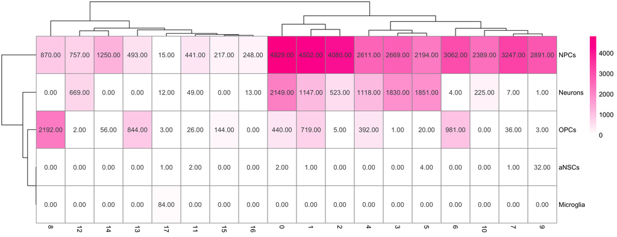

```r
df = obj.tmp@meta.data %>% select(RNA_snn_res.0.4, singleR_label) %>% table() %>% data.frame() %>% tidyr::spread(RNA_snn_res.0.4, Freq)
rownames(df) = df$singleR_label
df = df[,-1]
df %>% pheatmap::pheatmap(display_numbers = T, fontsize_number = "0f.%",
                          colorRampPalette(c("white", "#FF1493"))(75))
```

### Score Heatmap

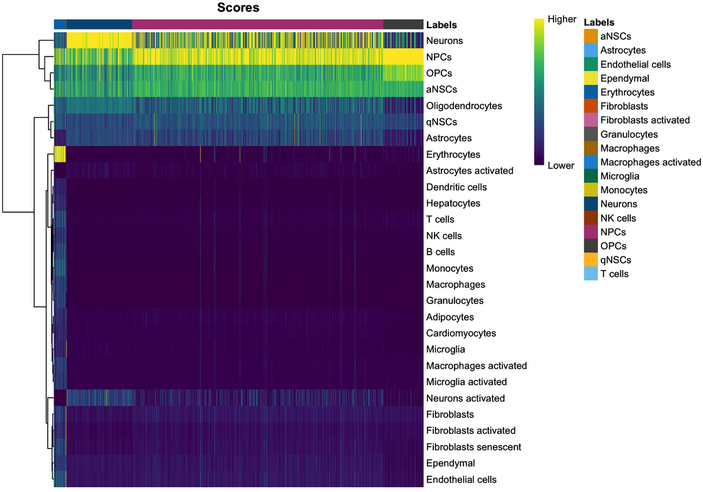

```r
SingleR::plotScoreHeatmap(pred2)
```

### Number of Cells

#### By SingleR annotation

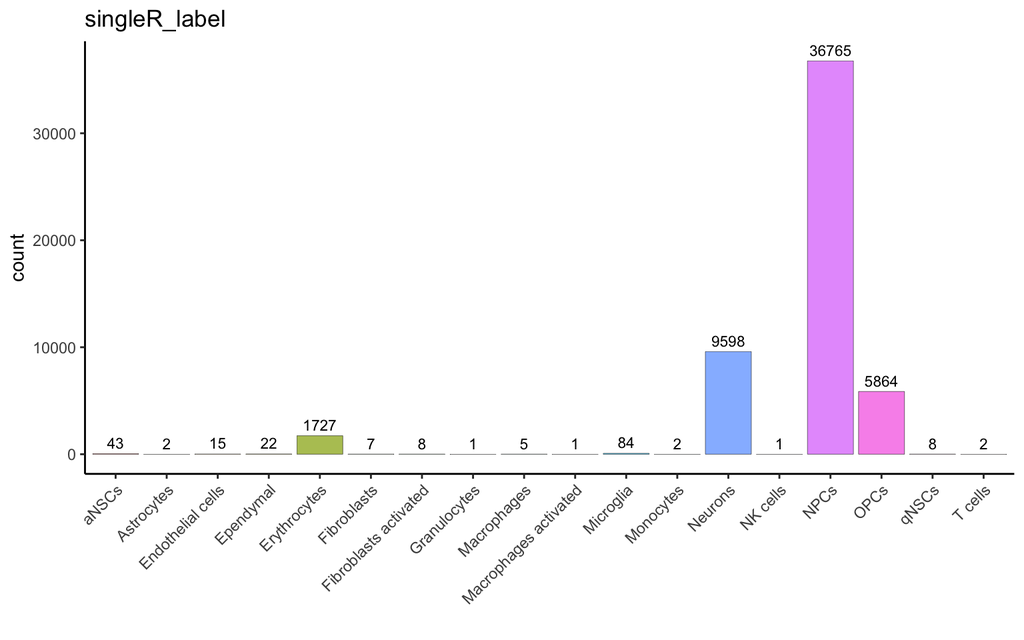

```r
res = "singleR_label"
obj.srt@meta.data %>% ggplot(aes(!!sym(res), fill=!!sym(res))) +
  geom_bar(alpha=0.7, color="grey5", size=0.1) +
  geom_text(stat="count", aes(label= ..count..), vjust=-0.5, size=3) +
  xlab("") +
  theme_classic() +
  theme(legend.title = element_blank(),
        legend.position = "none",
        axis.text.x = element_text(angle = 45, vjust=1, hjust=1)) +
  ggtitle(res)
```

#### By SingleR annotation (% of Cluster)

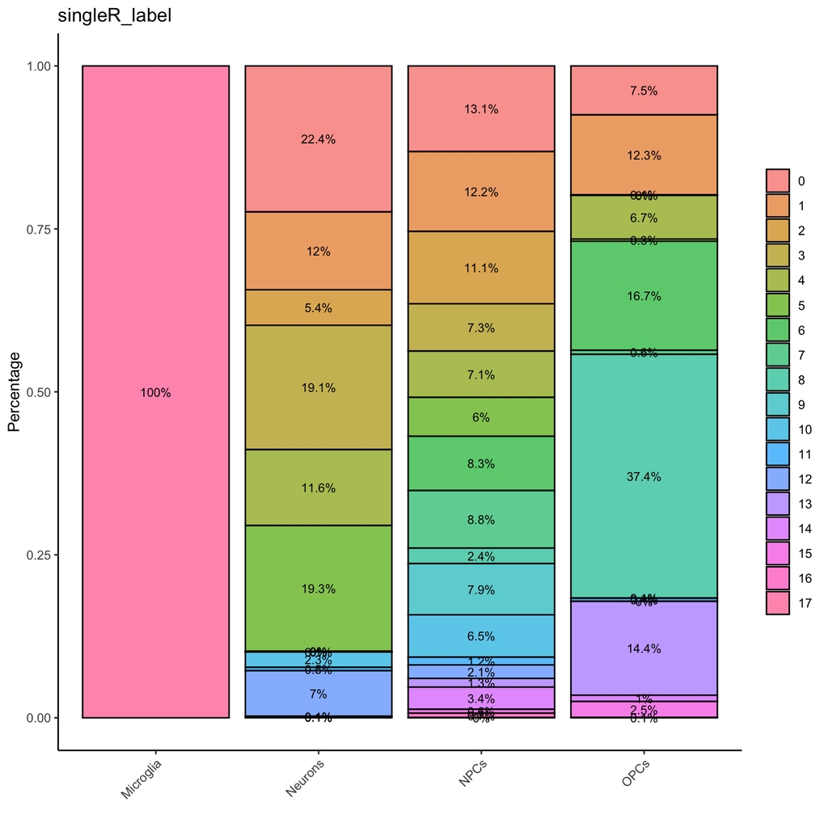

```r
meta_data <- as.data.frame(obj.srt@meta.data)

res <- "singleR_label"

meta_data_filtered <- meta_data %>%
  filter(singleR_label %in% c("Microglia", "Neurons", "NPCs", "OPCs")) %>%
  group_by(singleR_label, RNA_snn_res.0.4) %>%
  summarise(count = n(), .groups = "drop") %>%
  group_by(singleR_label) %>%
  mutate(percentage = count / sum(count) * 100)

# ggplot
ggplot(meta_data_filtered, aes(x = singleR_label, y = percentage, fill = RNA_snn_res.0.4)) +
  geom_bar(stat = "identity", alpha = 0.7, color = "black", position = "fill") +
  geom_text(
    aes(label = paste0(round(percentage, 1), "%")),
    position = position_fill(vjust = 0.5),  # 막대 중앙에 위치
    size = 3
  ) +
  xlab("") +
  ylab("Percentage") +
  theme_classic() +
  theme(
    legend.title = element_blank(),
    axis.text.x = element_text(angle = 45, vjust = 1, hjust = 1)
  ) +
  ggtitle(res)
```

#### By SingleR annotation (% of Cluster)

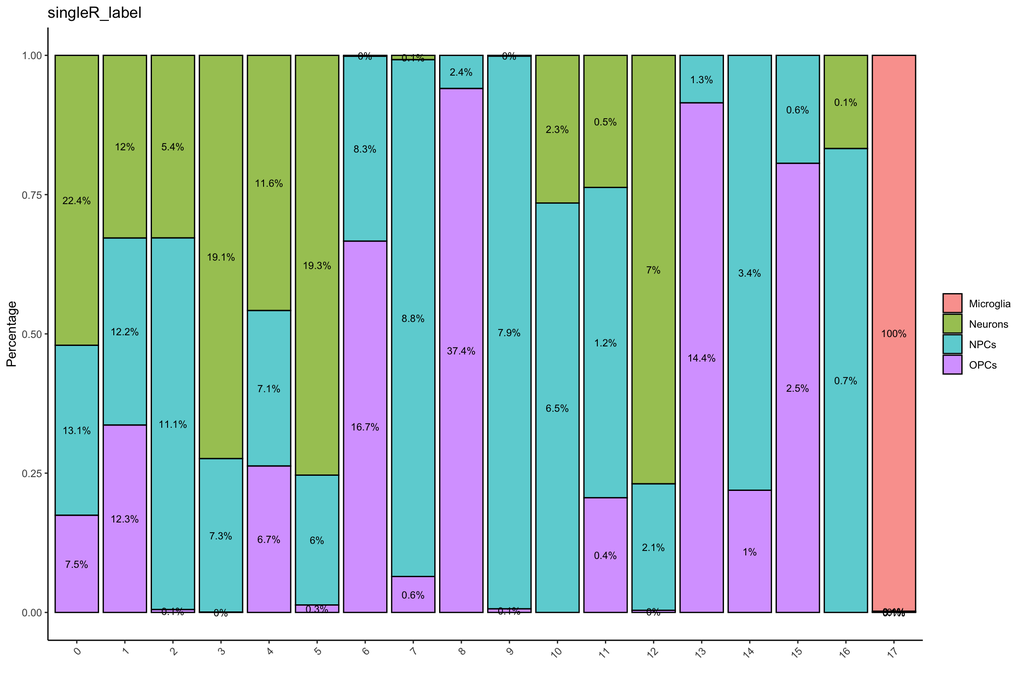

```r
meta_data <- as.data.frame(obj.srt@meta.data)

res <- "singleR_label"

meta_data_filtered <- meta_data %>%
  filter(singleR_label %in% c("Microglia", "Neurons", "NPCs", "OPCs")) %>%
  group_by(RNA_snn_res.0.4, singleR_label) %>%
  summarise(count = n(), .groups = "drop") %>%
  group_by(singleR_label) %>%
  mutate(percentage = count / sum(count) * 100)

# ggplot 작성
ggplot(meta_data_filtered, aes(x = RNA_snn_res.0.4, y = percentage,
                               fill = singleR_label)) +
  geom_bar(stat = "identity", alpha = 0.7, color = "black", position = "fill") +
  geom_text(
    aes(label = paste0(round(percentage, 1), "%")),
    position = position_fill(vjust = 0.5),  # 막대 중앙에 위치
    size = 3
  ) +
  xlab("") +
  ylab("Percentage") +
  theme_classic() +
  theme(
    legend.title = element_blank(),
    axis.text.x = element_text(angle = 45, vjust = 1, hjust = 1)
  ) +
  ggtitle(res)
```

#### Table

```r
meta_data_filtered %>% DT::datatable()
```

|  | RNA_snn_res.0.4 | singleR_label | count | percentage |
| --- | --- | --- | --- | --- |
| 1 | 0 | NPCs | 4829 | 13.13477492180063 |
| 2 | 0 | Neurons | 2149 | 22.39008126693061 |
| 3 | 0 | OPCs | 440 | 7.503410641200546 |
| 4 | 1 | NPCs | 4502 | 12.2453420372637 |
| 5 | 1 | Neurons | 1147 | 11.95040633465305 |
| 6 | 1 | OPCs | 719 | 12.2612551159618 |
| 7 | 2 | NPCs | 4080 | 11.09751121991024 |
| 8 | 2 | Neurons | 523 | 5.449051885809544 |
| 9 | 2 | OPCs | 5 | 0.08526603001364257 |
| 10 | 3 | NPCs | 2669 | 7.259621923024616 |

[output cut: 39 more lines]

### Additional Info

**Comparison: NPCs, OPCs, Neurons**

NPCs (Neural Progenitor Cells), OPCs (Oligodendrocyte Progenitor Cells), Neurons의 역할과 발현 시기를 비교

1. Neural Progenitor Cells (NPCs)

   • 역할: • 신경계 발달 초기에 발생하며, 뉴런, 별아교세포(Astrocytes), 희소돌기아교세포(Oligodendrocytes)로 분화할 수 있는 다능성 세포. • 신경계 재생과 유지에도 중요한 역할을 수행. • 발현 시기: • 발생 초기(Embryogenesis): 신경관(neural tube)이 형성된 후, 배아의 신경 발생 단계에서 NPCs는 가장 먼저 발현합니다. 뉴런 및 교세포로의 분화를 통해 초기 신경계를 형성합니다. • 성체(Adulthood): 신경생성(neurogenesis)이 유지되는 특정 영역(예: 해마의 치상회, 측뇌실 하부)에서 발견되며, 손상 복구 및 재생 과정에서 활성화됩니다. • 주요 발현 장소: • 발달 중인 신경관 및 성체 신경생성 영역.
2. Oligodendrocyte Progenitor Cells (OPCs)

   • 역할: • 희소돌기아교세포(Oligodendrocytes)로 분화하여 중추신경계(CNS)에서 미엘린 형성을 담당. • 미엘린은 뉴런의 축삭(axon)을 감싸 신경 신호 전달 속도를 증가시킵니다. • 신경계 손상 시 미엘린 재생과 축삭 보호 역할. • 발현 시기: • 배아 후기(Late Embryogenesis): NPCs가 OPCs로 분화되기 시작하며, 신경 발생이 어느 정도 진행된 이후에 발현됩니다. • 출생 후(Postnatal): 신경계 성숙 과정에서 활발히 증식하며 미엘린화를 진행. • 성체(Adulthood): 신경 손상이나 탈수초(demyelination) 질환이 발생하면 다시 활성화되어 희소돌기아교세포로 분화합니다. • 주요 발현 장소: • 중추신경계 전반.
3. Neurons

   • 역할: • 뉴런은 감각 정보 처리, 운동 신호 전달, 학습과 기억, 그리고 뇌의 고차원적 기능(인지 및 의사결정)을 담당. • 신경 신호를 전기적 및 화학적으로 생성, 전달. • 발현 시기: • 배아 중기(Mid-Embryogenesis): NPCs가 뉴런으로 분화하면서 신경계의 기본 구조가 형성되기 시작. • 출생 후(Postnatal): 성숙 과정을 통해 시냅스가 형성되고 뉴런 네트워크가 강화됨. • 성체(Adulthood): 기존 뉴런이 유지되며, 제한적이지만 성체 신경생성 영역에서는 새로운 뉴런 생성 가능. • 주요 발현 장소: • 중추신경계(뇌, 척수) 및 말초신경계.

발현 시기 비교

| 세포 유형 | 발생 초기 (Embryogenesis) | 출생 후 (Postnatal) | 성체 (Adulthood) |
| --- | --- | --- | --- |
| **NPCs** | 가장 먼저 발현 | 제한된 영역에서 유지 | 해마 등 신경생성 영역에서 활동 |
| **OPCs** | NPCs 이후 발현 | 미엘린화를 위해 활발히 활동 | 손상 시 활성화 및 미엘린 재생 |
| **Neurons** | NPCs가 분화하여 발현 | 시냅스 형성 및 뉴런 네트워크 강화 | 제한적으로 성체 신경생성 |

요약

```
•   NPCs는 신경 발생 초기에 발생하여 뉴런 및 OPCs의 전구체 역할을 수행하며, 성체에서도 신경 재생의 원천으로 작용합니다.
•   OPCs는 NPCs가 분화하여 형성되며, 신경계 성숙 단계에서 미엘린화를 통해 신경 신호 전달을 최적화합니다.
•   Neurons는 NPCs에서 발생하며, 신경계의 주요 기능을 수행하는 최종 분화 세포로서 초기 발달 단계부터 성숙한 상태까지 지속적으로 활동합니다.
```